# Deltas Notebook

Let’s import at all of the data that Simon and Matt pulled:

```r
library(tidyverse)
library(gridExtra)
library(maps)
library(ggthemes)


DeltasClean <- read_csv("../data/out/deltas_clean_v2.csv")
DeltaLocations <- read_csv("../data/DeltaLocations.csv")
```

[output not shown]

As a reminder, for each of the 47 deltas there are measurements of Land & Water areas at Upstream, Downstream and ‘Middle’ locations on the delta. We first lump all the observations together, and look to see which Deltas have many observations:

```r
#counts per delta
DeltaCounts <- count(DeltasClean, Delta)
DeltaCounts
```

| Delta | n |
| --- | --- |
| Amazon | 300 |
| Amur | 788 |
| Brahmani | 1115 |
| Burdekin | 1572 |
| Choa | 1133 |
| Colorado | 1370 |
| Congo | 225 |
| Danube | 1262 |
| Dnieper | 1473 |
| Ebro | 1515 |

[output cut: 37 more lines]

Now, by each month.. where the colorbar represents the number of observations (n) for each month for a given delta:

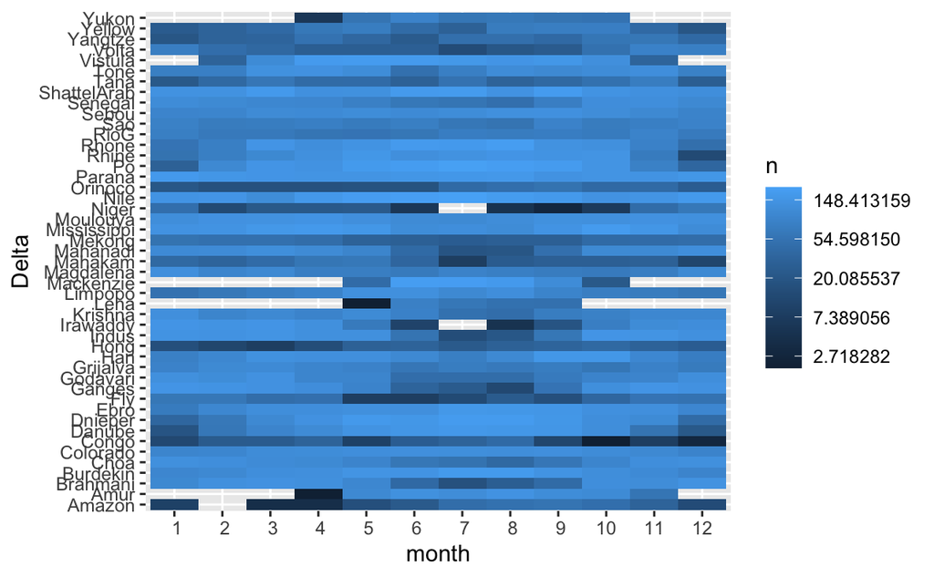

```r
DeltaObsPerMonth <- count(DeltasClean, Delta, month)

ggplot(DeltaObsPerMonth, aes(y = Delta, x = month, fill=n)) + geom_tile() +
  scale_x_discrete(limits = c(1:12), breaks = c(1:12)) +
  expand_limits(x = c(1,12)) +
  scale_fill_gradient( trans = 'log' )
```

In the above heat map, dark colors (and no color) represent data paucity (and data gaps). Deltas with light colors (e.g., the Parana, Nile, Ebro, Colorado, Brahmani) have lots of data, spread out through the months of the year.

I’ll remove/subset the deltas with sparse coverage (specifically, months with no coverage)….

```r
# need 10 data points per month for NDSSI and NDVI
EnoughObsPerMonth <- DeltasClean %>% ungroup() %>%
  count(Delta, month, surface) %>%
  group_by(surface) %>%
  filter( n >= 5)

#find deltas missing a given month of observations
DeltaMonthCounts <- EnoughObsPerMonth %>%
  ungroup() %>%
  count(Delta)

# need 12 months of water and land obs, so 24 mo total
EnoughMonths <- DeltaMonthCounts %>%
 filter( n == 24)

CompleteObsDeltas <- pull(EnoughMonths, Delta)

#remove them
DeltasCleaner <- DeltasClean %>%
  filter(Delta %in% CompleteObsDeltas)

#add the real dates in month date format
DeltasCleaner$date <- as.Date(paste(DeltasCleaner$year, DeltasCleaner$month, "01", sep="-"), "%Y-%m-%d")

#remove intermediate data
rm(CompleteObsDeltas, EnoughMonths, DeltaMonthCounts)

#EnoughMonths
```

and extract some metrics; specifically I will make a timeseries of NDVI and NDSSI for each delta using the mean value for each month.

From a quick look at the dat (not shown until much later in the doc):

```r
#take the mean NDVI and NDSSI for each month, for each delta
DeltaMeans <- DeltasCleaner %>%
  group_by(Delta, month, surface) %>%
  summarize(MeanNDVI = mean(ndvi, na.rm = TRUE), MeanNDSSI = mean(ndssi, na.rm = TRUE))

#make a 9 column data frame with:
#delta,
#max and min NDVI month,
#NDSSI max and min month,
#max and min values for both NDVI and NDSSI

#####

DeltaMaxNDVI <-
  DeltaMeans %>%
  filter(surface == 'Land')  %>%
  select (-c(MeanNDSSI)) %>%
  group_by(Delta) %>%
  slice(which.max(MeanNDVI)) %>%
  rename(MaxMeanNDVImonth = month, MaxMeanNDVI = MeanNDVI)

DeltaMaxNDSSI <-
  DeltaMeans %>%
  filter(surface == 'Water')  %>%
  select (-c(MeanNDVI)) %>%
  group_by(Delta) %>%
  slice(which.max(MeanNDSSI)) %>%
  rename(MaxMeanNDSSImonth = month, MaxMeanNDSSI = MeanNDSSI)


DeltaMinNDVI <-
  DeltaMeans %>%
  filter(surface == 'Land')  %>%
  select (-c(MeanNDSSI)) %>%
  group_by(Delta) %>%
  slice(which.min(MeanNDVI)) %>%
  rename(MinMeanNDVImonth = month, MinMeanNDVI = MeanNDVI)

DeltaMinNDSSI <-
  DeltaMeans %>%
  filter(surface == 'Water')  %>%
  select (-c(MeanNDVI)) %>%
  group_by(Delta) %>%
  slice(which.min(MeanNDSSI)) %>%
  rename(MinMeanNDSSImonth = month, MinMeanNDSSI = MeanNDSSI)


#join into 1 dataframe
DeltaMaxMin <- left_join(DeltaMaxNDVI, DeltaMaxNDSSI, by = 'Delta') %>%
  left_join(.,DeltaMinNDVI, by = 'Delta') %>%
  left_join(.,DeltaMinNDSSI, by = 'Delta')

#remove intermediate data
rm(DeltaMaxNDVI, DeltaMaxNDSSI, DeltaMinNDSSI,DeltaMinNDVI)
```

And now we can look at the phase shifts between these two time series (the timeseries of mean NDVI and mean NDSSI). Here are the phase shifts (in month) for each delta:

```r
#compare offset
DeltaMaxMin <- mutate(DeltaMaxMin,
                      MinOffset = if_else(abs(MinMeanNDVImonth - MinMeanNDSSImonth) > 6,
                                          12 - abs(MinMeanNDVImonth - MinMeanNDSSImonth),
                                          abs(MinMeanNDVImonth - MinMeanNDSSImonth)),
                      MaxOffset = if_else(abs(MaxMeanNDVImonth - MaxMeanNDSSImonth) > 6,
                                         12 - abs(MaxMeanNDVImonth - MaxMeanNDSSImonth),
                                          abs(MaxMeanNDVImonth - MaxMeanNDSSImonth)),
                      OffsetDiff = abs(MaxOffset - MinOffset),
                      rangeNDVI = (MaxMeanNDVI - MinMeanNDVI),
                      rangeNDSSI = (MaxMeanNDSSI - MinMeanNDSSI))

# DeltaMaxMin <-
#   DeltaMaxMin   %>%
#   select (c(Delta, MinOffset, MaxOffset, OffsetDiff, rangeNDVI, rangeNDSSI,MaxMeanNDSSI,MinMeanNDSSI,MaxMeanNDVI,MinMeanNDVI))

DeltaMaxMin
```

| Delta | MaxMeanNDVImonth | surface.x | MaxMeanNDVI | MaxMeanNDSSImonth | surface.y | MaxMeanNDSSI | MinMeanNDVImonth | surface.x.x | MinMeanNDVI | MinMeanNDSSImonth | surface.y.y | MinMeanNDSSI | MinOffset | MaxOffset | OffsetDiff | rangeNDVI | rangeNDSSI |
| --- | --- | --- | --- | --- | --- | --- | --- | --- | --- | --- | --- | --- | --- | --- | --- | --- | --- |
| Brahmani | 8 | Land | 0.66498168 | 12 | Water | 0.13712630 | 5 | Land | 0.44254329 | 7 | Water | -0.118404762 | 2 | 4 | 2 | 0.22243839 | 0.2555311 |
| Burdekin | 2 | Land | 0.52698904 | 8 | Water | 0.34078551 | 10 | Land | 0.39782098 | 2 | Water | -0.051982562 | 4 | 6 | 2 | 0.12916806 | 0.3927681 |
| Choa | 7 | Land | 0.71788809 | 1 | Water | 0.19557709 | 3 | Land | 0.61108484 | 8 | Water | -0.003734228 | 5 | 6 | 1 | 0.10680325 | 0.1993113 |
| Colorado | 2 | Land | 0.07384282 | 5 | Water | -0.03370475 | 8 | Land | 0.05887065 | 2 | Water | -0.158603868 | 6 | 3 | 3 | 0.01497217 | 0.1248991 |
| Dnieper | 7 | Land | 0.73059539 | 12 | Water | 0.34370273 | 2 | Land | 0.22035925 | 6 | Water | -0.056911658 | 4 | 5 | 1 | 0.51023614 | 0.4006144 |
| Ebro | 7 | Land | 0.51355457 | 12 | Water | 0.44799145 | 3 | Land | 0.34012635 | 8 | Water | 0.094722984 | 5 | 5 | 0 | 0.17342822 | 0.3532685 |
| Godavari | 2 | Land | 0.51606963 | 12 | Water | 0.22557364 | 6 | Land | 0.34925481 | 8 | Water | -0.228230778 | 2 | 2 | 0 | 0.16681482 | 0.4538044 |
| Grijalva | 11 | Land | 0.74909897 | 2 | Water | 0.18572031 | 4 | Land | 0.61157948 | 7 | Water | -0.011156769 | 3 | 3 | 0 | 0.13751949 | 0.1968771 |
| Han | 6 | Land | 0.36246280 | 12 | Water | 0.25130236 | 3 | Land | 0.08433893 | 4 | Water | 0.127554891 | 1 | 6 | 5 | 0.27812387 | 0.1237475 |
| Indus | 9 | Land | 0.24411538 | 12 | Water | 0.39130249 | 7 | Land | 0.14702230 | 8 | Water | -0.092697261 | 1 | 3 | 2 | 0.09709308 | 0.4839998 |

[output cut: 21 more lines]

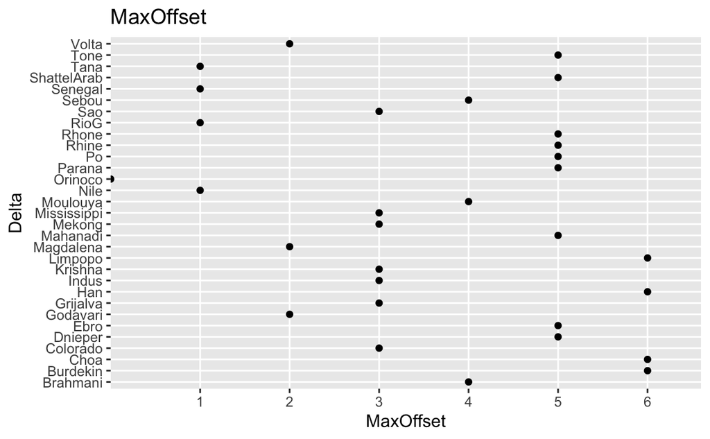

```r
ggplot(DeltaMaxMin, aes(y = Delta, x = MaxOffset)) + geom_point() +
  scale_x_discrete(limits = c(1:6), breaks = c(1:6)) +
  expand_limits(x = c(0,6))  +
  ggtitle("MaxOffset")
```

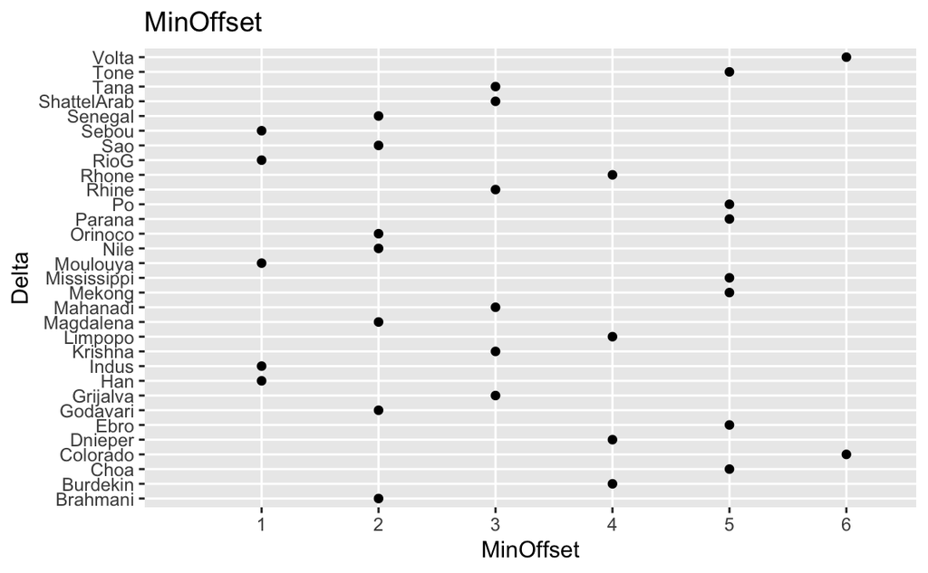

```r
ggplot(DeltaMaxMin, aes(y = Delta, x = MinOffset)) + geom_point() +
  scale_x_discrete(limits = c(1:6), breaks = c(1:6)) +
  expand_limits(x = c(0,6))  +
  ggtitle("MinOffset")
```

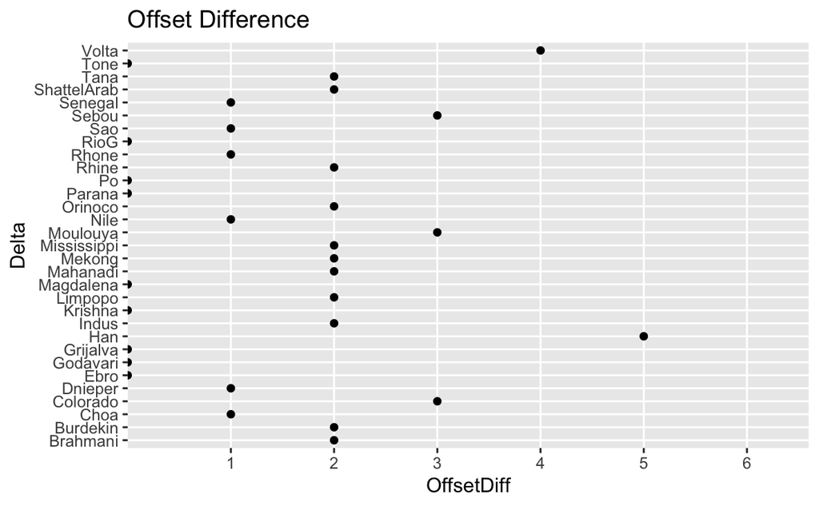

```r
ggplot(DeltaMaxMin, aes(y = Delta, x = OffsetDiff)) + geom_point() +
  scale_x_discrete(limits = c(1:6), breaks = c(1:6)) +
  expand_limits(x = c(0,6))  +
  ggtitle("Offset Difference")
```

And here are the phase shifts/offsets against other measured parameters for each delta. The range, max and mean of NDVI and NDSSI is calculated from the timeseries, so it is really the max, min, and range of the monthly means (i.e., the maximum of the means, the minimum of the means, and the range of the mean). Offset is measured in months.

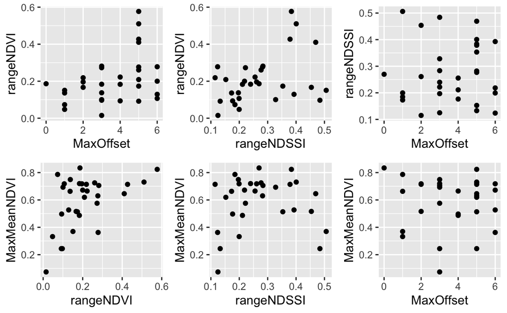

```r
slice1 <- ggplot(DeltaMaxMin, aes(y = rangeNDVI, x = MaxOffset)) + geom_point()
# + scale_x_discrete(limits = c(1:6), breaks = c(1:6)) + expand_limits(x = c(1,6))

slice2 <- ggplot(DeltaMaxMin, aes(y = rangeNDVI, x = rangeNDSSI)) + geom_point()
slice3 <- ggplot(DeltaMaxMin, aes(y = rangeNDSSI, x = MaxOffset)) + geom_point()

slice4 <- ggplot(DeltaMaxMin, aes(y = MaxMeanNDVI, x = rangeNDVI)) + geom_point()
slice5 <- ggplot(DeltaMaxMin, aes(y = MaxMeanNDVI, x = rangeNDSSI)) + geom_point()
slice6 <- ggplot(DeltaMaxMin, aes(y = MaxMeanNDVI, x = MaxOffset)) + geom_point()

slice7 <- ggplot(DeltaMaxMin, aes(y = MaxMeanNDSSI, x = MaxMeanNDVI)) + geom_point()
slice8 <- ggplot(DeltaMaxMin, aes(y = MaxMeanNDSSI, x = rangeNDSSI)) + geom_point()
slice9 <- ggplot(DeltaMaxMin, aes(y = MaxMeanNDSSI, x = MaxOffset)) + geom_point()
slice10 <- ggplot(DeltaMaxMin, aes(y = MaxMeanNDSSI, x = rangeNDVI)) + geom_point()

grid.arrange(slice1, slice2, slice3, slice4, slice5, slice6, ncol=3)
```

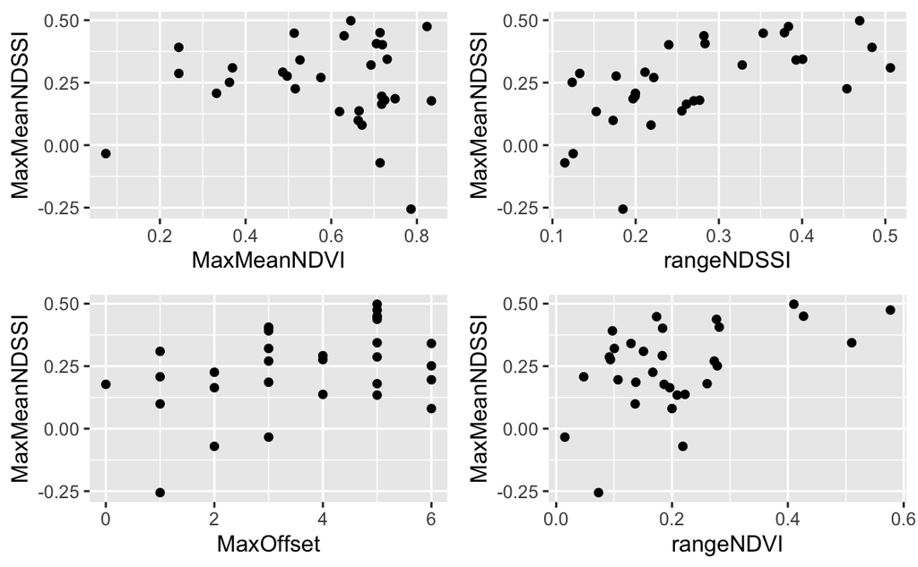

```r
grid.arrange(slice7, slice8, slice9, slice10, ncol=2)
```

```r
#remove those panels
rm(slice1, slice2, slice3, slice4, slice5, slice6,slice7, slice8, slice9, slice10)
```

Join Latitude and longitude data

```r
DeltaDatawLocations <- left_join(DeltaMaxMin, DeltaLocations, by = c("Delta" = "Deltas"))

DeltaDatawLocations <- DeltaDatawLocations %>%
  mutate(Absolute_Latitude= abs(Lat))
```

plot params vs lat

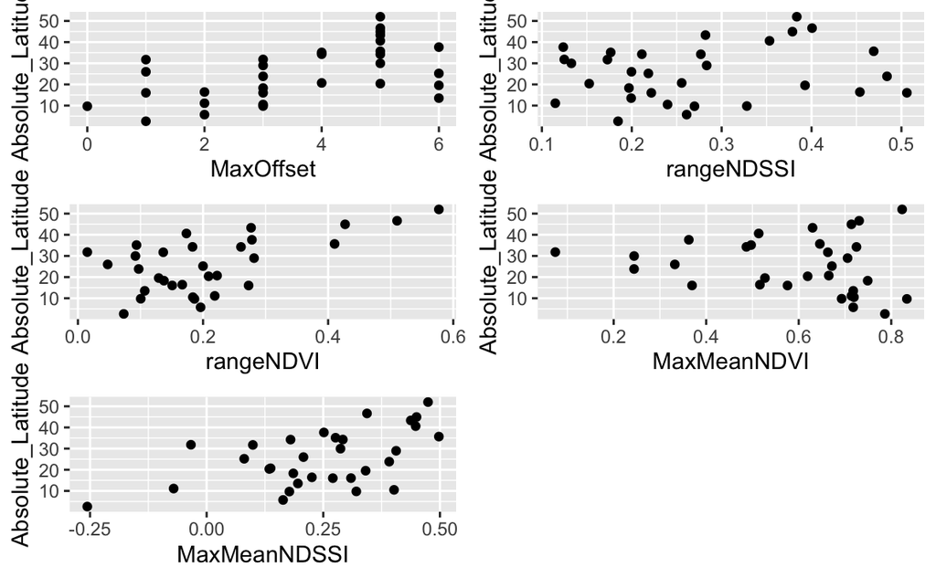

```r
loc1 <- ggplot(DeltaDatawLocations, aes(y = Absolute_Latitude, x = MaxOffset)) + geom_point()
loc2 <- ggplot(DeltaDatawLocations, aes(y = Absolute_Latitude, x = rangeNDSSI)) + geom_point()
loc3 <- ggplot(DeltaDatawLocations, aes(y = Absolute_Latitude, x = rangeNDVI)) + geom_point()
loc4 <- ggplot(DeltaDatawLocations, aes(y = Absolute_Latitude, x = MaxMeanNDVI)) + geom_point()
loc5 <- ggplot(DeltaDatawLocations, aes(y = Absolute_Latitude, x = MaxMeanNDSSI)) + geom_point()

grid.arrange(loc1, loc2, loc3, loc4, loc5, ncol=2)
```

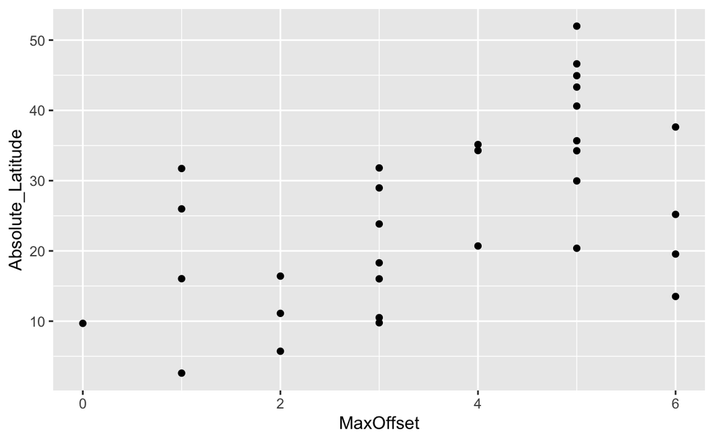

```r
loc1
```

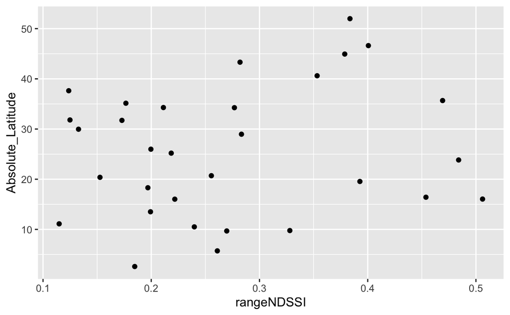

```r
#ggsave("loc1.pdf", width = 4, height = 4)
loc2
```

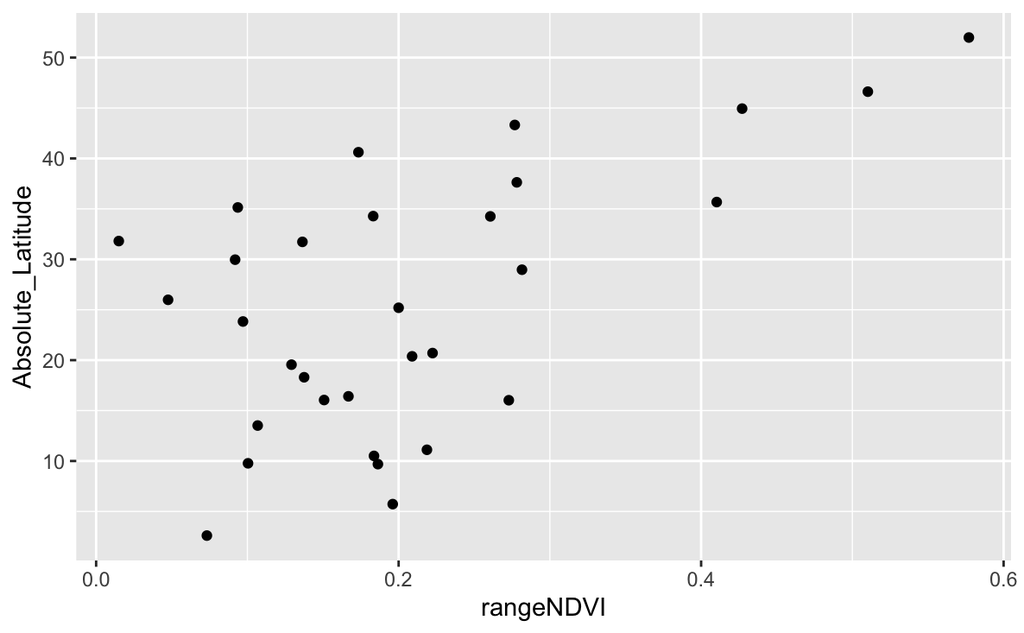

```r
#ggsave("loc2.pdf", width = 4, height = 4)
loc3
```

```r
#ggsave("loc3.pdf", width = 4, height = 4)

#remove those panels
rm(loc1, loc2, loc3, loc4, loc5)
```

```r
#find the linear model
DeltaOffset_lm <- lm( Absolute_Latitude ~ MaxOffset, data = DeltaDatawLocations)

summary(DeltaOffset_lm)
```

```
Call:
lm(formula = Absolute_Latitude ~ MaxOffset, data = DeltaDatawLocations)

Residuals:
    Min      1Q  Median      3Q     Max
-21.779  -8.983   0.775   8.377  20.772

Coefficients:
            Estimate Std. Error t value Pr(>|t|)
(Intercept)   10.820      4.629   2.337  0.02653 *
MaxOffset      4.079      1.157   3.525  0.00143 **
---
Signif. codes:  0 ‘***’ 0.001 ‘**’ 0.01 ‘*’ 0.05 ‘.’ 0.1 ‘ ’ 1

Residual standard error: 11.06 on 29 degrees of freedom
Multiple R-squared:  0.2999,    Adjusted R-squared:  0.2758
F-statistic: 12.43 on 1 and 29 DF,  p-value: 0.001428
```

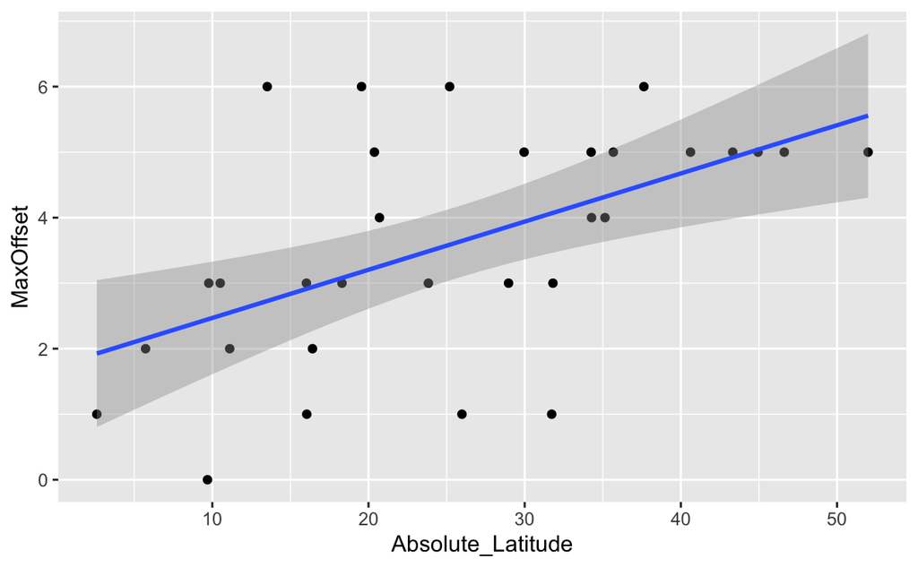

```r
ggplot(DeltaDatawLocations, aes(x = Absolute_Latitude, y = MaxOffset)) +
  geom_point() +
  geom_smooth(mapping = aes(x = Absolute_Latitude, y = MaxOffset, ), method=lm )
```

```r
NA
NA
NA
```

Now for the maps:

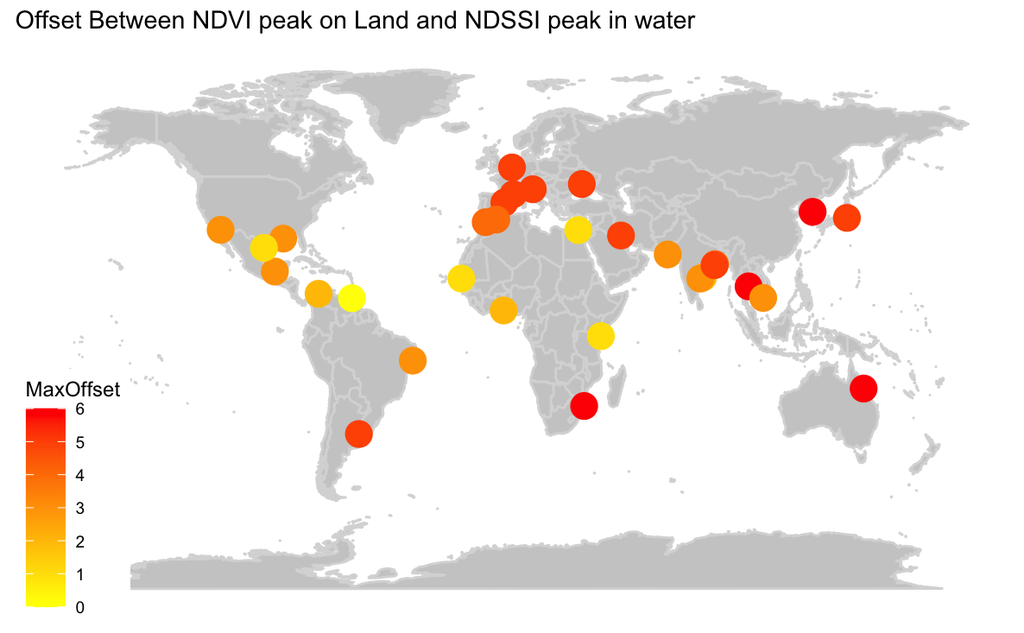

```r
world <- ggplot() +
  borders("world", colour = "gray85", fill = "gray80") +
  theme_map()

DeltaOffsetMap <- world +
  geom_point(aes(x = Lon, y = Lat, color = MaxOffset),
             data = DeltaDatawLocations,
             size = 5) + scale_color_gradient( high = "red", low  = "yellow") +
  ggtitle("Offset Between NDVI peak on Land and NDSSI peak in water")

DeltaOffsetMap
```

```r
#ggsave("DeltaOffsetMap.pdf", width = 6, height = 4)
```

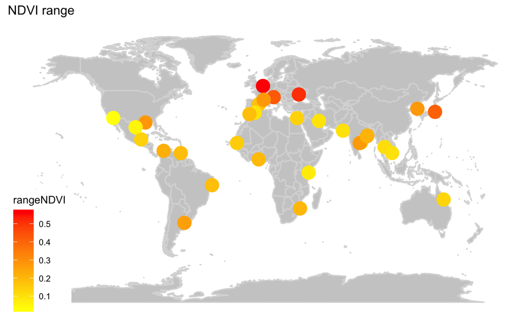

```r
world <- ggplot() +
  borders("world", colour = "gray85", fill = "gray80") +
  theme_map()

DeltaNDVIrangeMap <- world +
  geom_point(aes(x = Lon, y = Lat, color = rangeNDVI),
             data = DeltaDatawLocations,
             size = 5) + scale_color_gradient( high = "red", low  = "yellow") +
  ggtitle("NDVI range")


DeltaNDSSIrangeMap  <- world +
  geom_point(aes(x = Lon, y = Lat, color = rangeNDSSI),
             data = DeltaDatawLocations,
             size = 5) + scale_color_gradient( high = "red", low = "yellow") + ggtitle("NDSSI range")

DeltaNDVIrangeMap
```

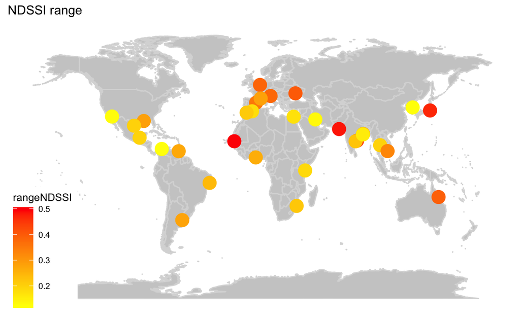

```r
#ggsave("DeltaNDVIrangeMap.pdf", width = 6, height = 4)
DeltaNDSSIrangeMap
```

```r
#ggsave("DeltaNDSSIrangeMap.pdf", width = 6, height = 4)
```

Let’s look at some of the data. To quantify the water, we use NDSSI. to quantify land, we use NDVI.here is the time series for the Parana.

```r
DeltaPlotter <- function(DeltaName) {
  #Counts each month
  numVeg <- DeltasCleaner %>%
    select(Delta, surface, month, ndvi) %>%
    filter(Delta == DeltaName & surface == "Land" & !is.na(ndvi)) %>%
    group_by(month) %>%
    summarize(n = n())

  numSed <- DeltasCleaner %>%
    select(Delta, surface, month, ndssi) %>%
    filter(Delta == DeltaName &
             surface == "Water" & !is.na(ndssi)) %>%
    group_by(month) %>%
    summarize(n = n())

  #Highlight the Maximum and Minimum Month for each delta, NDVI and NDSSI

  #LAND
  Veg <-
    ggplot(data = filter(DeltasCleaner, Delta == DeltaName &
                           surface == "Land")) +
    geom_boxplot(aes(x = month, y = ndvi, group = month)) +
    scale_x_discrete(limits = c(1:12), breaks = c(1:12)) +
    expand_limits(x = c(1, 12)) +
    ggtitle(DeltaName) +
    #geom_text(data = numVeg, aes(y = 1.05, x = month, label = n)) +
    geom_boxplot(
      data = filter(
        DeltasCleaner,
        Delta == DeltaName &
          surface == "Land" & month == DeltaMaxMin$MaxMeanNDVImonth[DeltaMaxMin$Delta == DeltaName]
      ),
      aes(x = month, y = ndvi, group = month),
      fill = "green"
    ) +
    geom_boxplot(
      data = filter(
        DeltasCleaner,
        Delta == DeltaName &
          surface == "Land" & month == DeltaMaxMin$MinMeanNDVImonth[DeltaMaxMin$Delta ==DeltaName]
      ),
      aes(x = month, y = ndvi, group = month),
      fill = "blue"
    )


  Sed <-
    ggplot(data = filter(DeltasCleaner, Delta == DeltaName &
                           surface == "Water")) +
    geom_boxplot(aes(x = month, y = ndssi, group = month)) +
    scale_x_discrete(limits = c(1:12), breaks = c(1:12)) +
    expand_limits(x = c(1, 12)) +
    #geom_text(data = numSed, aes(y = 1.05, x = month, label = n)) +
    geom_boxplot(
      data = filter(
        DeltasCleaner,
        Delta == DeltaName &
          surface == "Water" & month == DeltaMaxMin$MaxMeanNDSSImonth[DeltaMaxMin$Delta == DeltaName]
      ),
      aes(x = month, y = ndssi, group = month),
      fill = "green"
    ) +
    geom_boxplot(
      data = filter(
        DeltasCleaner,
        Delta == DeltaName &
          surface == "Water" & month == DeltaMaxMin$MinMeanNDSSImonth[DeltaMaxMin$Delta == DeltaName]
      ),
      aes(x = month, y = ndssi, group = month),
      fill = "blue"
    )

  return(grid.arrange(Veg, Sed, nrow = 2))
}
```

Here is an ‘Offset’ example from the Parana:

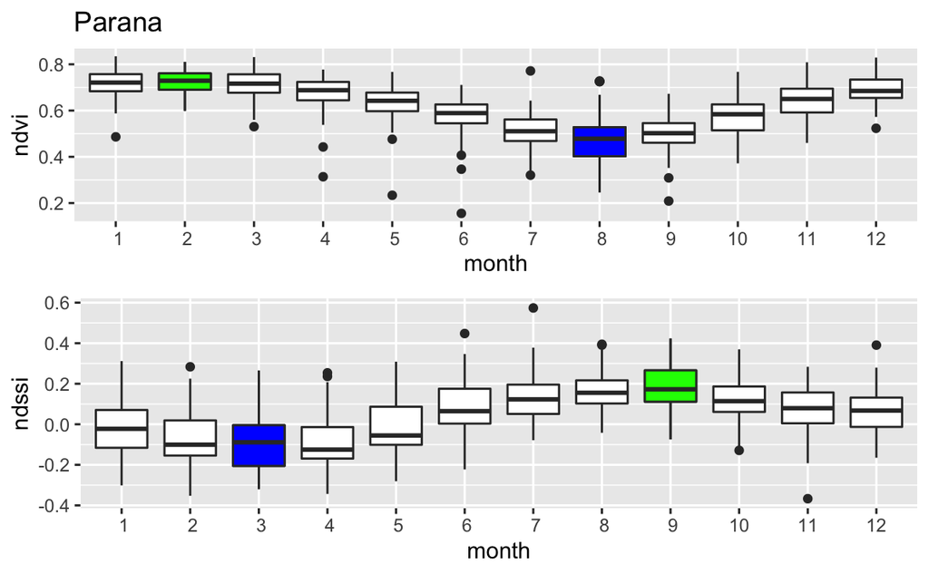

```r
DeltaPlotter("Parana")
```

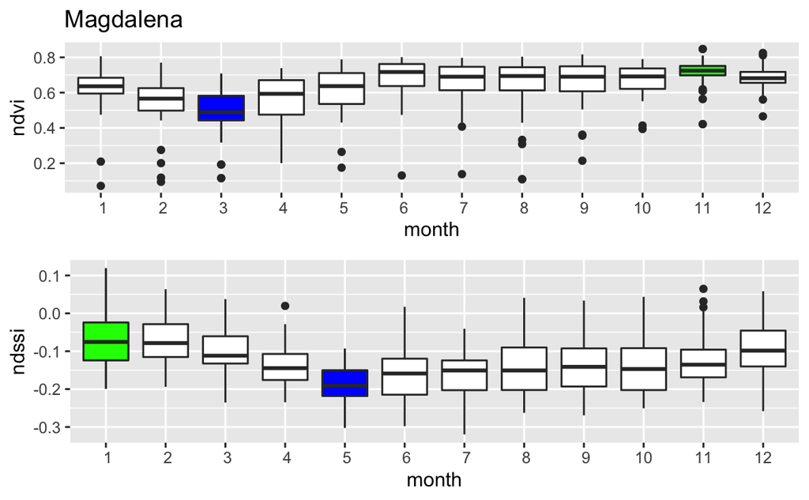

```r
DeltaPlotter("Magdalena")
```

and the Ebro:

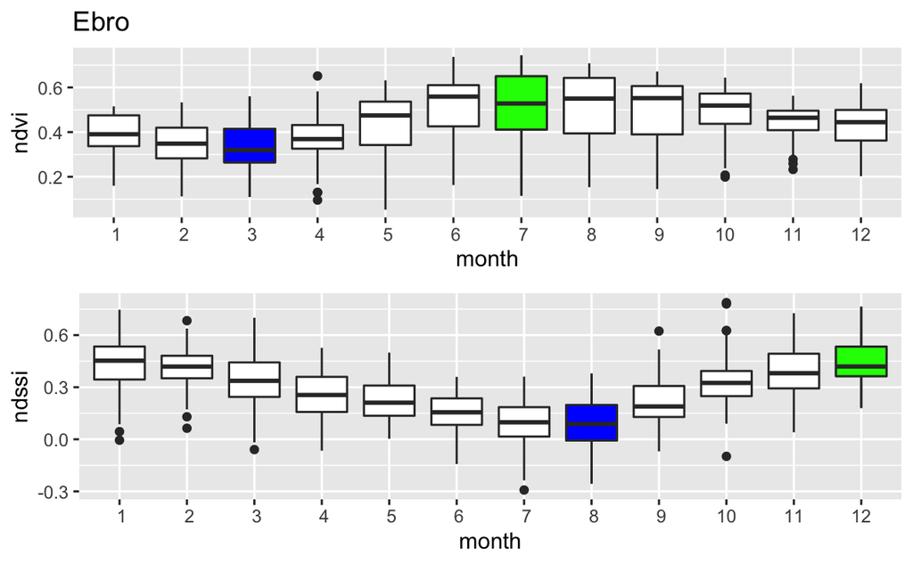

```r
DeltaPlotter("Ebro")
```

and the Tana

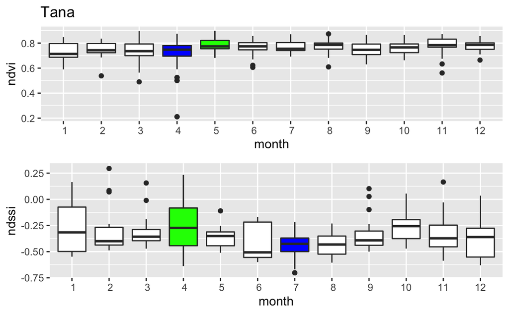

```r
DeltaPlotter("Tana")
```

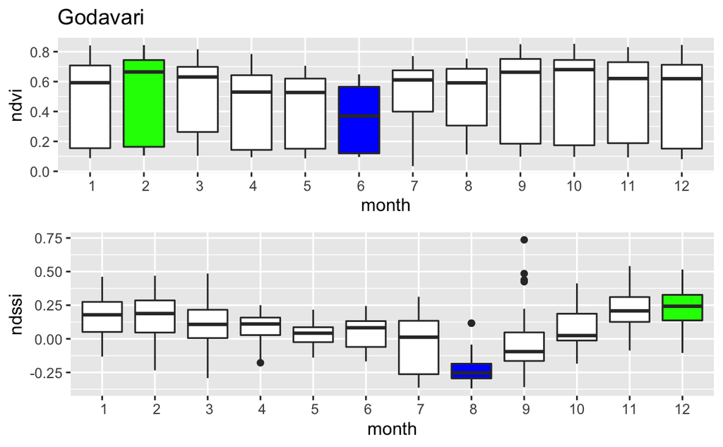

```r
DeltaPlotter("Godavari")
```

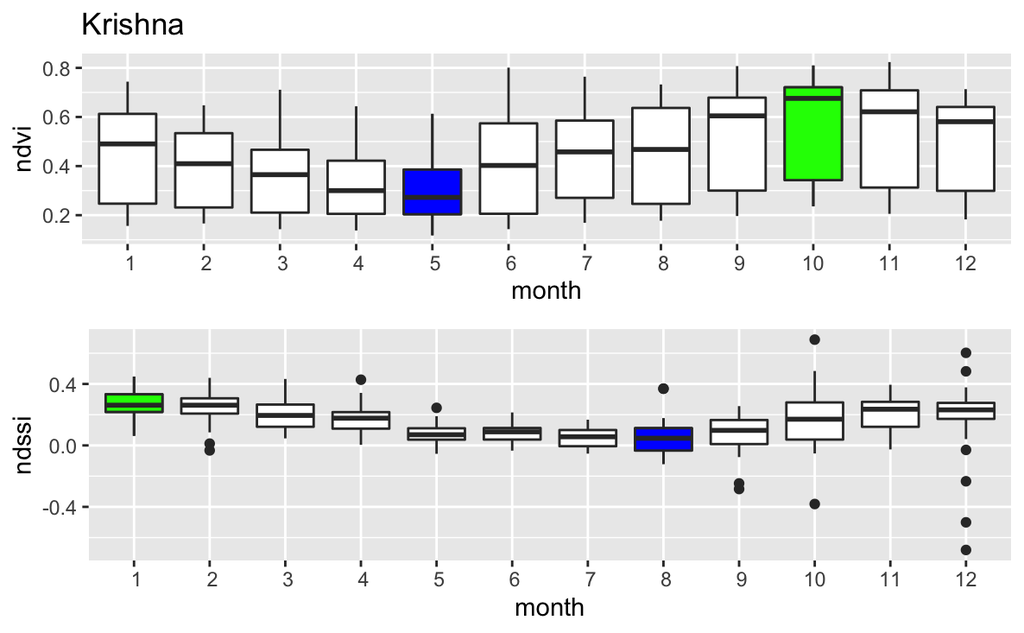

```r
DeltaPlotter("Krishna")
```

Now for some work with GRDC data:

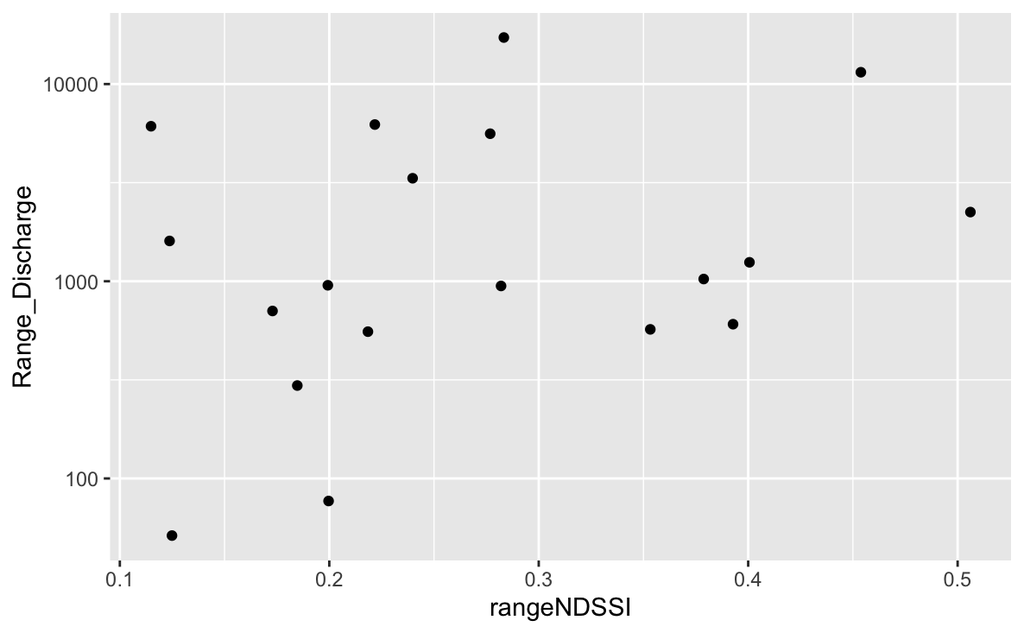

```r
#import the data (monthly means for 21 stations)
DeltasGRDC  <- read_csv("../data/GRDCstations.csv")
#calculate the mean of the monthly means
DeltasGRDCwMean <- DeltasGRDC %>%
    rowwise() %>%
    mutate(MMD=mean(c(January,February,March,April,
                    May,June,July,August,
                    September,October,November,December)))

DeltasGRDCwMean <- DeltasGRDCwMean %>%
  rowwise() %>%
  mutate(Range_Discharge = max(c(January,February,March,April,
              May,June,July,August,
              September,October,November,December)) -
           min(c(January,February,March,April,
              May,June,July,August,
              September,October,November,December))
           )


#join to location data:
DeltawLocGRDC <- left_join(DeltaDatawLocations, DeltasGRDCwMean, by = c("Delta" = "Deltas"))


#plot mean of monthly means against NDSSI
ggplot(DeltawLocGRDC, aes(y = Range_Discharge, x = rangeNDSSI)) + geom_point() + scale_y_continuous(trans='log10')
```

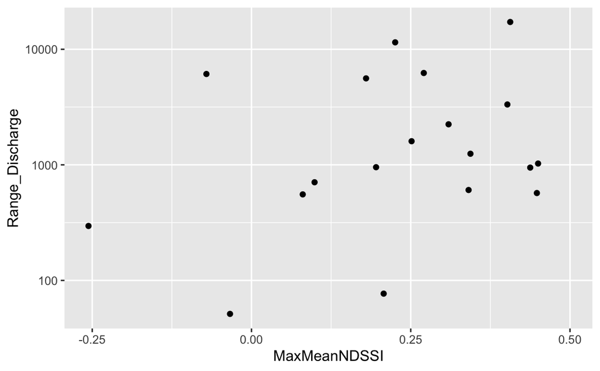

```r
#ggsave("GRDCNDSSI.pdf", width = 6, height = 4)

ggplot(DeltawLocGRDC, aes(y = Range_Discharge, x = MaxMeanNDSSI)) + geom_point() + scale_y_continuous(trans='log10')
```